# Sequential Monte Carlo

5 Oct 2016

## But first an intro to Rcpp

Recall the rejection sampler from the Gaussian distribution,

```r
rgaus <- function(n) {
  y <- numeric(n)
  for(i in 1:n) {
    ratio <- 0
    u <- 1
    while(u > ratio) {
      y0 <- rexp(1) - rexp(1)
      ratio <- exp(- y0^2 / 2 - 0.5 + abs(y0))
      u <- runif(1)
    }
    y[i] <- y0
  }
  y
}
```

## Using `cppFunction`

```r
library(Rcpp)
cppFunction('NumericVector rgausFast(int n) {
  NumericVector y(n);
  double ratio, u, y0;
  for(int i = 0; i < n; i++) {
    ratio = 0;
    u = 1;
    while(u > ratio) {
      y0 = rexp(1)[0] - rexp(1)[0];
      ratio = exp(- y0 * y0 / 2 - 0.5 + std::abs(y0));
      u = runif(1)[0];
    }
    y[i] = y0;
  }
  return y;
}'
)
```

## Testing

```r
set.seed(05102016)
rgaus(10)
```

```
 [1] -0.67789569  1.14521645  1.39843999  0.04680905 -1.42131797
 [6] -0.25511250  1.11350875 -0.11479537 -0.22645695 -0.09719512
```

```r
set.seed(05102016)
rgausFast(10)
```

```
 [1] -0.67789569  1.14521645  1.39843999  0.04680905 -1.42131797
 [6] -0.25511250  1.11350875 -0.11479537 -0.22645695 -0.09719512
```

## Benchmarking

```r
library(microbenchmark)
microbenchmark(rgaus(1), rgausFast(1))
```

```
Unit: microseconds
         expr min   lq mean median   uq max neval cld
     rgaus(1) 7.2 10.7 18.5     11 19.0 435   100   b
 rgausFast(1) 1.5  1.8  3.6      3  3.3  35   100  a
```

```r
microbenchmark(rgaus(100), rgausFast(100))
```

```
Unit: microseconds
           expr min  lq mean median   uq  max neval cld
     rgaus(100) 713 793 1102    890 1280 2288   100   b
 rgausFast(100)  23  26   30     28   31   64   100  a
```

## Multivariate distributions

Distributions on \(\mathbb{R}^n\) can be specified by a density. A well known example is the multivariate normal distribution.

How should we simulate from a distribution on \(\mathbb{R}^n\) with density \(f\)?

- If the coordinates are independent, we can simulate them marginally.
- For the multivariate normal distribution \(\mathcal{N}(\mu, \Sigma)\) simulation can be done as \(X = C Z + \mu\), with \(Z \sim \mathcal{N}(0, I)\) and \(\Sigma = CC^T\).
- Rejection and importance sampling can be used, but choosing a good envelope becomes increasingly difficult as \(n\) increases.

## Sequential sampling

Suppose that \(X_0 = U_0\) and \[X_k = \alpha X_{k-1} + U_k\] for \(k = 1, \ldots, n\), where \(U_0, \ldots, U_n\) are i.i.d. \(\mathcal{N}(0, 1)\)-distributed.

Then \[X_k = (C U)_k = \alpha^k U_0 + \alpha^{(k-1)} U_1 + \ldots + U_k\] with \(C_{k,l} = \alpha^{k-l}1(k \geq l)\), and \(X = (X_k)_{k=0}^n \sim \mathcal{N}(0, CC^T)\).

It is much faster to use the recursive (sequential) formula than the matrix multiplication for simulation.

## Colorado flight

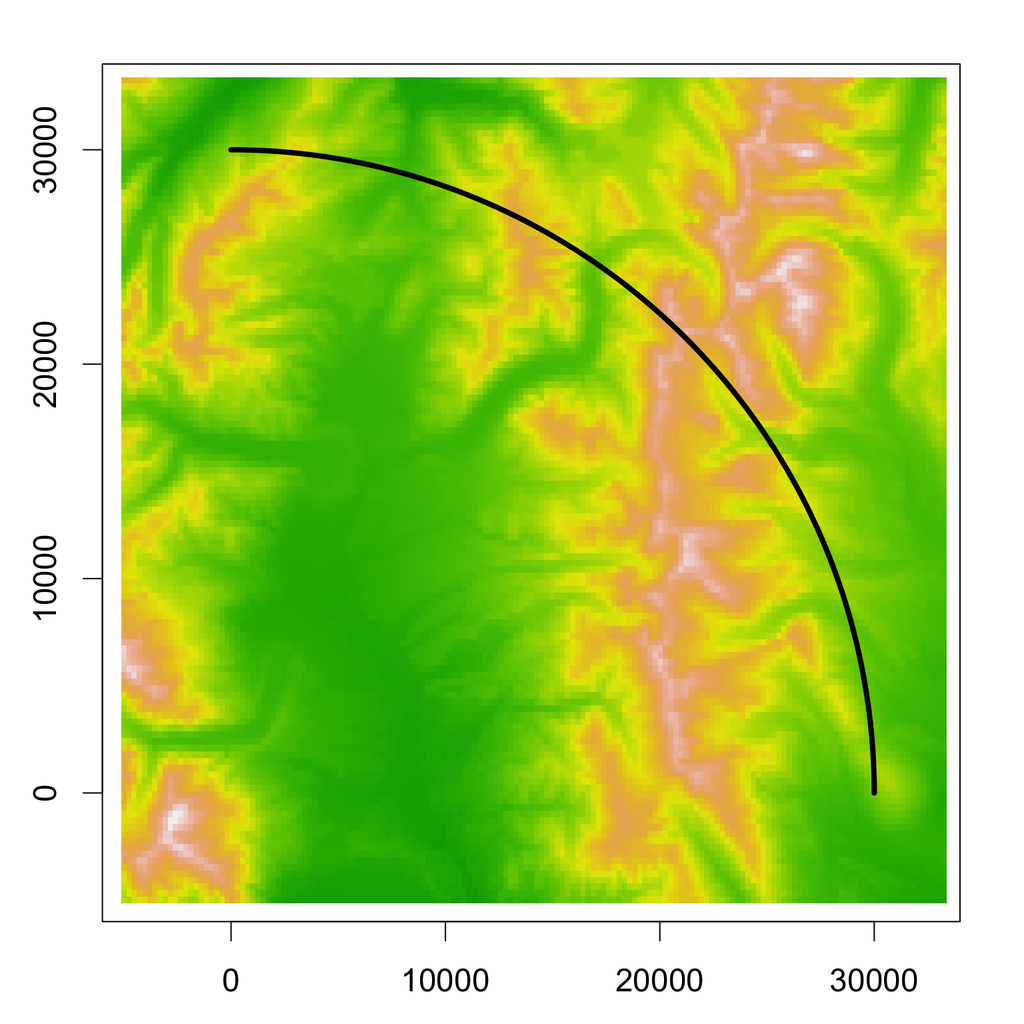

## Colorado flight

Let \(X_t \in \mathbb{R}^2\) denote the position at time \(t\), then \[X_t = X_{t-1} + d_t\] with \(d_t\) the *velocity*.

If we observe \(d_t\) then \[X_t = X_0 + \sum_{s=1}^t d_s.\]

## Colorado flight, cumulative errors

If we observe \(\tilde{d}_t = d_t - \epsilon_t\) then \[\tilde{X}_t = X_0 + \sum_{s=1}^t \tilde{d}_s = X_t + \sum_{s = 1}^t \epsilon_s.\]

Our *naive* prediction of position drifts away by cumulation of errors.

## Colorado flight, adding errors

```r
head(path)
```

```
     [,1]  [,2]
[1,]    0 30000
[2,]  471 29996
[3,]  942 29985
[4,] 1413 29967
[5,] 1884 29941
[6,] 2354 29908
```

```r
tilded <- rbind(path[1, ], apply(path, 2, diff) +
                  rnorm(2 * nrow(path) - 2, 0, 300))
```

## Colorado flight path with cumulative errors

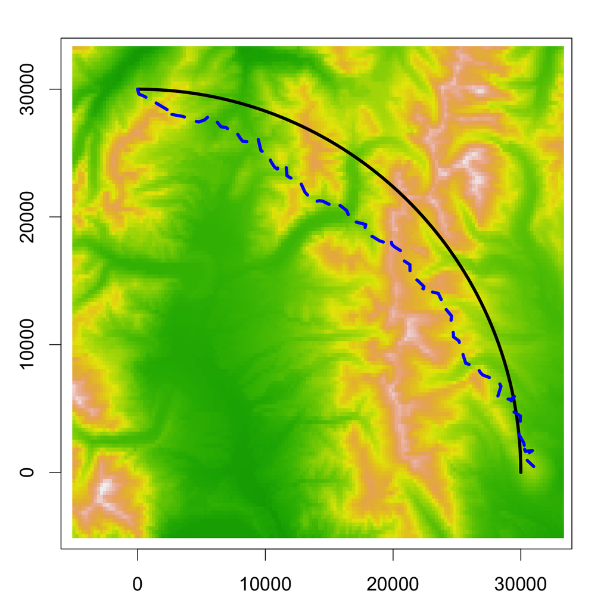

## Inertial navigation systems

A combination of measurements from gyroscopes and accelerometers combined with knowledge of initial velocity can be used to compute the velocity at any given later time.

This is in itself a summation (or integration) process, where errors are accumulated.

In this example we suppose for simplicity that velocity is reported by the inertial navigation system as \[\tilde{d}_t = d_t - \epsilon_t\]

Then \[X_t = X_{t-1} + \tilde{d}_t + \epsilon_t.\]

## Corrections

Additional measurements \[Y_t = m(X_t) + \delta_t\] with \(\delta_t\) i.i.d. might be used to correct for the cumulation of errors, if the map \(m : \mathbb{R}^2 \to \mathbb{R}\) is informative about the position.

For the Colorado flight, \(m\) is the ground elevation.

**How do we incorporate the additional measurements into the summation of the noisy velocities to correct for the errors?**

## Markov Chains

A sequence \(X_0, X_1, \ldots\) given by update formulas \[X_t = F_t(X_{t-1}, U_t)\] for \(U_t\) i.i.d. and \(F_t\) fixed maps is a *Markov chain*.

The *process* on slide 3, \[X_k = \alpha X_{k-1} + U_k,\] is an example of a Markov chain known as the AR(1)-process (autoregressive process with lag 1).

For the AR(1)-process, \(F(x, u) = \alpha x + u.\)

## Flight models

We will consider two navigation models of this form.

**Model 1:** Let \[F_t(x, u) = x + \tilde{d}_t + u\] and \(\epsilon_t = U_t\).

**Model 2:** Let \[F_t(x, u) = x + \tilde{d}_t + \sigma(x)u\] and \(\epsilon_t = \sigma(X_{t-1})U_t\).

## Markov Chains

If the distribution of \(F_t(x, U_t)\) has density \(f_t(\cdot \mid x)\), the density of \(X_0, \ldots, X_t\) is \[ \begin{aligned} f_t(x_{0:t}) & = f_0(x_0) f_1(x_1\mid x_0) \ldots f_t(x_t \mid x_{t-1}) \\ & = f_{t-1}(x_{0:(t-1)}) f_t(x_t \mid x_{t-1}), \end{aligned} \] where \(f_0\) is the density of \(X_0\).

We call \(f_t(\cdot \mid x)\) the *transition density* at time \(t\). If it doesn't depend upon \(t\) we call the Markov chain *time homogeneous*.

The AR(1)-process is time homogeneous. If also \(U_t \sim \mathcal{N}(0, 1)\), the transition density is the Gaussian density with mean \(\alpha x\) and variance \(1\).

## Hidden Markov models

Let \(X_0, X_1, \ldots\) be a Markov chain and \[Y_t = G_t(X_t, \delta_t)\] for \(\delta_t\) i.i.d. and \(G_t\) a fixed function.

If the distribution of \(G_t(x, \delta_t)\) has density \(g_t(\cdot \mid x)\), the joint distribution of \((X_0, Y_0), \ldots, (X_t, Y_t)\) has density \[k_t(x_{0:t}, y_{0:t}) = f_t(x_{0:t}) g_t(y_{0:t} \mid x_{0:t})\] where \[g_t(y_{0:t} \mid x_{0:t}) = g_0(y_0 \mid x_0) g_1(y_1 \mid x_1) \ldots g_t(y_t \mid x_t). \]

For navigation, \(G_t(x, \delta) = m(x) + \delta.\)

## Navigation

Knowing the noisy velocities and the initial position the HMM allows for a generation of paths and related elevation measurements.

We are interested in reversing this process.

Given the elevation measurements and velocities we are interested in computing the path.

Specifically, we want to compute \[E (X_t \mid Y_0 = y_0, \ldots, Y_t = y_t),\] as a prediction of the position at time \(t\) given the elevation measurements up to time \(t\).

## Bayes' Theorem

## Bayes' Theorem

\[P(A \mid B) = \frac{P(B \mid A) P(A)}{P(B)}\]

Or for random variables \[ \begin{aligned} P(X \in A \mid Y \in B) & = \frac{P(Y \in B \mid X \in A) P(X \in A)}{P(Y \in B)} \end{aligned} \]

Or for point probabilities \[ \begin{aligned} P(X = x \mid Y = y) & = \frac{P(Y = y \mid X = x) P(X = x)}{P(Y = y)} \end{aligned} \]

## Bayes' Theorem

It is a little more tricky for continuous random variables because one-point sets have probability zero.

That \(Y \mid X = x\) has conditional density \(g(y \mid x)\) means *by definition* that \[ \begin{aligned} P(X \in A, Y \in B) & = \int_A \int_B \underbrace{g(y \mid x) f(x)}_{\textrm{joint dens.}} \ dy dx \end{aligned} \]

## Bayes' Theorem

Note that \[g(y \mid x) f(x) = \frac{g(y \mid x) f(x)}{g(y)} g(y).\]

Hence \[P(X \in A, Y \in B) = \int_B \int_A \frac{g(y \mid x) f(x)}{g(y)} g(y) \ dx dy.\]

And by the definition of conditional densities,  
\[f(x \mid y) = \frac{g(y \mid x) f(x)}{g(y)}.\]

## Hidden Markov Models

The *conditional density* of \(Y_0, \ldots, Y_t\) given \(X_0 = x_0, \ldots, X_t = x_t\) is  
\[g_t(y_{0:t} \mid x_{0:t}).\]

By Bayes' theorem, the conditional density of \(X_0, \ldots, X_t\) given \(Y_0 = y_0, \ldots, Y_t = y_t\) is \[f_t(x_{0:t} \mid y_{0:t}) = \frac{g_t(y_{0:t} \mid x_{0:t}) f_t(x_{0:t})}{g_t(y_{0:t})}.\]

## Hidden Markov Models

The numerator, \[g_t(y_{0:t} \mid x_{0:t}) f_t(x_{0:t})\] is directly computable.

The denominator, \[g_t(y_{0:t}) = \int k_t(x_{0:t}, y_{0:t}) \ d x_{0:t},\] is not.

It is the marginal density for \(Y_0, \ldots Y_t\), and it is an *unknown normalization constant* for the conditional density.

## Sequential importance sampling

An importance sampler of \[f_t(x_{0:t} \mid y_{0:t}) \propto g_t(y_{0:t} \mid x_{0:t}) f_t(x_{0:t})\] is obtained by sampling from \(f_t\) (the Markov chain itself).

Then the importance weights will be \[w^{(i)*}_t = g_t(y_{0:t} \mid X^{(i)}_{0:t}) = \prod_{s=0}^t u_s^{(i)}\] where \(u_s^{(i)} = g_s(y_s \mid X^{(i)}_{s})\).

## Importance sampling

Since sampling from the Markov chain and computing the weights are carried out sequentially from \(s = 0\) to \(s = t\) this is the *sequential importance sampler*.

We can compute \[E(X_t \mid Y_0 = 0, \ldots, Y_t = y_t) \simeq \sum_{i=1}^n X_t^{(i)} w^{(i)}_t\] with the *standardized weights* \[w^{(i)}_t = \frac{w^{(i)*}_t}{\sum_{i=1}^n w^{(i)*}_t}.\]

## The \(m\)-function

```r
mfun <- function(x1, x2) {
  x1 <- round((x1 + 5000) / 240.62) + 1
  x2 <- round((x2 + 5000) / 308.37) + 1
  x1 <- pmin(pmax(x1, 1), 160)
  x2 <- pmin(pmax(x2, 1), 125)
  elev[x1 + (x2 - 1) * nrow(elev)]
}
```

## Importance sampling filter

```r
impfilt <- function(y, x0, n, d, qsigma, sigma, sigma0 = 50) {
  t <- length(y)
  d <- array(rep(d, each = n), dim = c(n, t, 2))
  x <- array(0, dim = c(n, t, 2))
  u <- w <- matrix(1 / n, n, t)
  x[, 1, ] <- matrix(rnorm(2 * n, rep(x0, n), sigma0),
                     n, 2, byrow = TRUE)
  for(s in 2:t) {
    x[, s, ] <- x[, s - 1, ] + d[, s, ] + rnorm(2 * n, 0, qsigma)
    u[, s] <- dnorm(y[s], mfun(x[, s, 1], x[, s, 2]), sigma)
    w[, s] <- u[, s] * w[, s - 1]
    w[, s] <- w[, s] / sum(w[, s])
  }
  list(x = x, u = u, w = w)
}
```

## Colorado flight

```r
qsigma <- 100  ## Small variance
sigma <- 15    ## Small variance
tilded <- rbind(path[1, ], apply(path, 2, diff) +
                  rnorm(2 * nrow(path) - 2, 0, qsigma))
yobs <- mfun(path[, 1], path[, 2]) + rnorm(nrow(path), 0, sigma)
filt <- impfilt(yobs, tilded[1, ], 5000, tilded, qsigma, sigma)
pathhat <- cbind(colSums(filt$x[, , 1] * filt$w),
                 colSums(filt$x[, , 2] * filt$w))
sort(filt$w[, 101], decreasing = TRUE)[1:20]
```

```
 [1]  1.0e+00  1.5e-87 8.7e-112 1.4e-158 2.0e-167 1.5e-172 1.3e-175
 [8] 2.9e-181 3.3e-192 3.1e-200 4.0e-205 1.8e-207 7.9e-211 6.2e-213
[15] 3.2e-221 6.4e-222 1.7e-233 2.8e-235 1.0e-247 1.7e-251
```

## Colorado flight

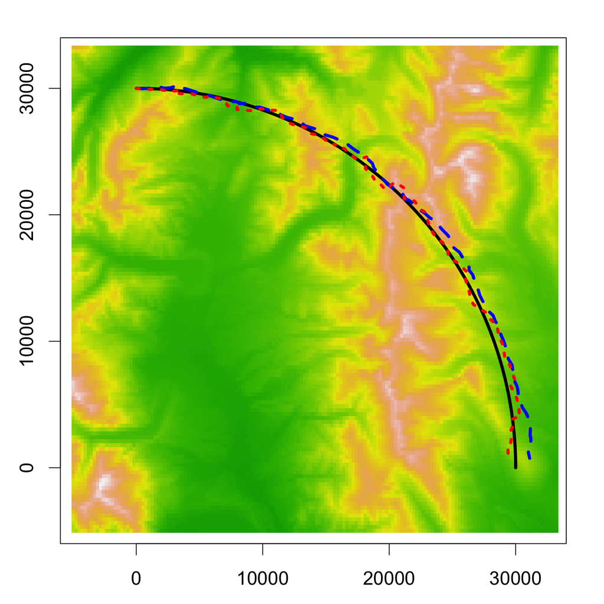

## Colorado flight

```r
qsigma <- 300; sigma <- 75   ## Larger variances
```

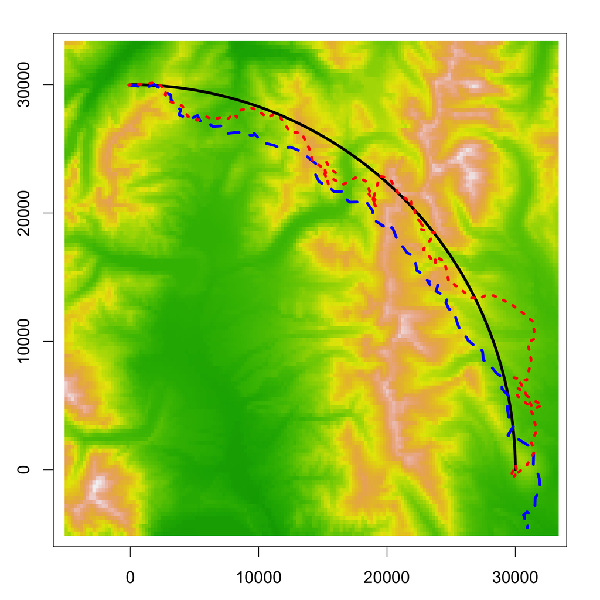

## Weight histograms

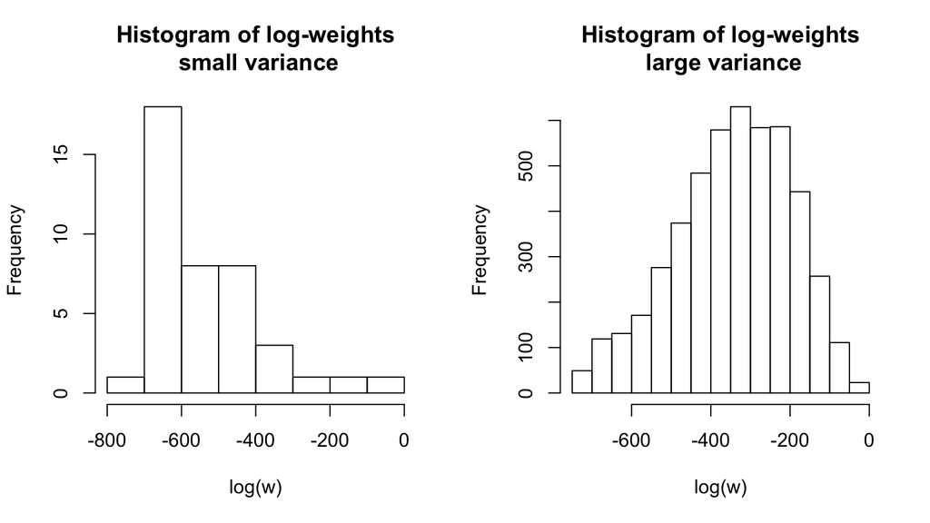

The weights have degenerated. Most of them are effectively zero!

## Importance sampling and resampling

Weight degeneracy is closely related to the envelope not being optimal.

How can we adaptively get rid of the "bad" proposals of a non-optimal envelope?

The solution is closely related to the ability to *approximately* sample from \(f_s(\cdot\mid y_{0:s})\) using *sampling importance resampling* (SIR).

## SIR

If \(X^{(1)}, \ldots, X^{(n)}\) are i.i.d. importance samples with standardized weights \(w^{(1)}, \ldots, w^{(n)}\) the measure \[\nu^{(n)} := \sum_{i=1}^n w^{(i)} \delta_{X^{(i)}}\] is an approximation of the target distribution.

We can draw *approximate* samples from the target by sampling from \(\nu^{(n)}\), which is the same as sampling from \(X^{(1)}, \ldots, X^{(n)}\) with replacement with probabilities \(w^{(1)}, \ldots, w^{(n)}\).

This is the SIR algorithm.

## Resampling

To counteract the *weight degeneracy* in sequential importance sampling we can *resample* in some or all steps of the algorithm.

The *bootstrap filter* resamples in every step:

- Sample \(n\) observations from \(\nu_s^{(n)}.\)  
  (This is \(n\) approximate samples from \(f_s(\cdot \mid y_{0:s})\). )
- Replace \(X^{(1)}_s, \ldots, X^{(n)}_s\) by the resampled observations.
- Replace the weights by \(1/n\).

## Bootstrap filter

```r
bootfilt <- function(y, x0, n, d, qsigma, sigma, sigma0 = 50) {
  t <- length(y)
  d <- array(rep(d, each = n), dim = c(n, t, 2))
  x <- xre <- array(0, dim = c(n, t, 2))
  u <- matrix(1 / n, n, t)
  x[, 1, ] <- matrix(rnorm(2 * n, rep(x0, n), sigma0),
                     n, 2, byrow = TRUE)
  xre[, 1, ] <- x[, 1, ]
  for(s in 2:t) {
    x[, s, ] <- xre[, s - 1, ] + d[, s, ] + rnorm(2 * n, 0, qsigma)
    u[, s] <- dnorm(y[s], mfun(x[, s, 1], x[, s, 2]), sigma)
    resamp <- sample(n, n, replace = TRUE, prob = u[, s])
    xre[, s, ] <- x[resamp, s, ]
  }
  list(x = x, u = u)
}
```

## Colorado flight

```r
qsigma <- 300
sigma <- 75
tilded <- rbind(path[1, ], apply(path, 2, diff) +
                  rnorm(2 * nrow(path) - 2, 0, qsigma))
yobs <- mfun(path[, 1], path[, 2]) + rnorm(nrow(path), 0, sigma)
filt <- bootfilt(yobs, tilded[1, ], 5000, tilded, qsigma, sigma)
pathhat <- cbind(colSums(filt$x[, , 1] * filt$u),
                 colSums(filt$x[, , 2] * filt$u)) / colSums(filt$u)
```

## Average distance from true path

```r
sqrt(sum((path - apply(tilded, 2, cumsum))^2) / 100)
```

```
[1] 2939
```

```r
sqrt(sum((path - pathhat)^2) / 100)
```

```
[1] 1004
```

## Colorado flight

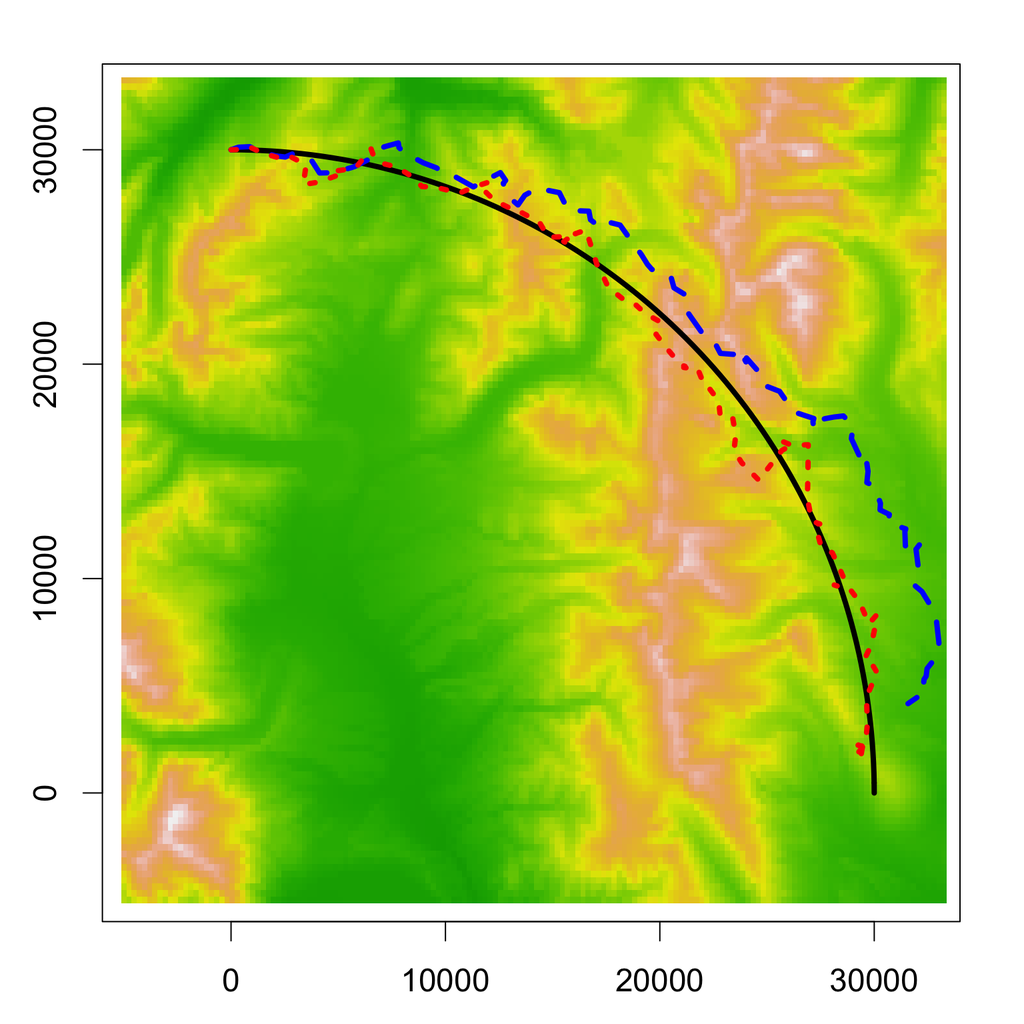

## Homework for Monday

- Write a bootstrap filter in R for the simpler univariate model, where \(X_t\) is an AR(1)-process (with \(\alpha = 0.9\), say) and \(Y_t = X_t + \delta_t\).
- Convert the bootstrap filter into Rcpp code.
- Use Rcpp for one of your assignment solutions.